# t-Test_1

Jesse

2019年11月26日

As we learnt before, there are three types of t-Test.

- One sample: H<sub>0</sub>: u = u<sub>0</sub>
- Paired sample: H<sub>0</sub>: u<sub>diff</sub> = u<sub>0</sub>
- Two independent samples: H<sub>0</sub>: u<sub>1</sub> - u<sub>2</sub> = u<sub>0</sub>

To support such variety types of statistics, `t.test` has many arguments for us to set to fit different type of t-Test.

```
t.test(x, y = NULL,
       alternative = c("two.sided", "less", "greater"),
       mu = 0, paired = FALSE, var.equal = FALSE,
       conf.level = 0.95, ...)
```

Today, we gonna learn how to conduct first two types of t-Test.

## One sample

In one-sampe t-Test, we test whether the mean of a vector is different from the theotrical mean.

For example, we heard that average NBA player height is 2.00 meters in 2008-9 season.  
We wanna check if it’s true, so we use **nba_heights** data (https://www.openintro.org/stat/data.php?data=nba_heights) to check whether average NBA player height in 2008-9 is 2 meters.

```r
## insert data

nba_heights <- read.csv("C:/Users/asus/Desktop/TA/TA session/week11/nba_heights.csv")

## easy analytics: summary statistics and histogram

## get sample mean
mean(nba_heights$h_meters)
```

```
## [1] 2.012483
```

```r
## get sample variance
var(nba_heights$h_meters)
```

```
## [1] 0.008114098
```

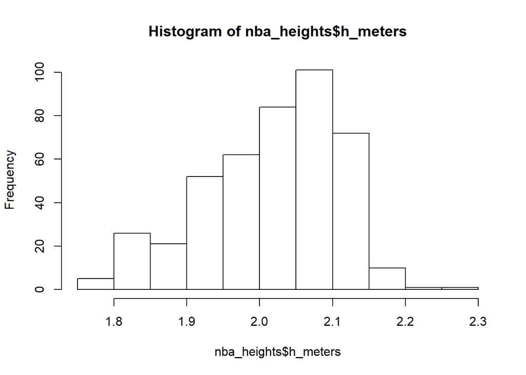

```r
## get histogram to see heights distribution
hist(nba_heights$h_meters)
```

Finally, we gonna do one-sample t-Test.  
Here, we need to set arguements `mu` and is able to try to change `conf.level` as the default setting is 0.95.

```r
t.test(nba_heights$h_meters, mu = 2)
```

```
##
##  One Sample t-test
##
## data:  nba_heights$h_meters
## t = 2.8902, df = 434, p-value = 0.004042
## alternative hypothesis: true mean is not equal to 2
## 95 percent confidence interval:
##  2.003994 2.020971
## sample estimates:
## mean of x
##  2.012483
```

```r
#change confidence interval to 90%
t.test(nba_heights$h_meters, mu = 2, conf.level = 0.9)
```

```
##
##  One Sample t-test
##
## data:  nba_heights$h_meters
## t = 2.8902, df = 434, p-value = 0.004042
## alternative hypothesis: true mean is not equal to 2
## 90 percent confidence interval:
##  2.005364 2.019602
## sample estimates:
## mean of x
##  2.012483
```

### Question

We believe that NBA player average height is 79 inches in 2018-19 season.  
Use the following data **nba_players_19** (https://www.openintro.org/stat/data.php?data=nba_players_19) to verify whether it’s true.

## Paired Sample

The paired sample t-test is used to compare the means between two related groups of samples.  
In this case, we would have two values for the same samples.

As there are few datasets for paired sample t-test,  
here we directly make one dataset **exercising**.  
We simulate 100 people’s weight before and after exercising three time every week for a year.

```r
set.seed(1215)
before <- rnorm(100, 70, 10)
after <- rnorm(100, 68, 10)

exercising <- data.frame("before" = before, "after" = after)
t.test(exercising$before, exercising$after, paired = TRUE)
```

```
##
##  Paired t-test
##
## data:  exercising$before and exercising$after
## t = 2.5091, df = 99, p-value = 0.01373
## alternative hypothesis: true difference in means is not equal to 0
## 95 percent confidence interval:
##  0.7591711 6.4989461
## sample estimates:
## mean of the differences
##                3.629059
```

Thereafter, still, we do some easy statistics and plots.

```r
mean(exercising$before)
```

```
## [1] 71.82772
```

```r
var(exercising$before)
```

```
## [1] 114.8725
```

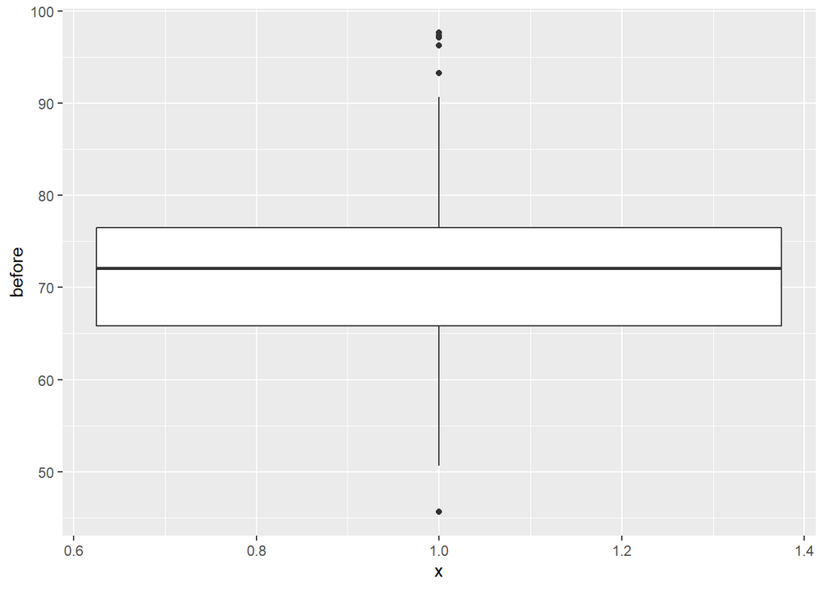

```r
ggplot(data = exercising) +
  geom_boxplot(mapping = aes(x=1, y=before))
```

```r
mean(exercising$after)
```

```
## [1] 68.19866
```

```r
var(exercising$after)
```

```
## [1] 109.5731
```

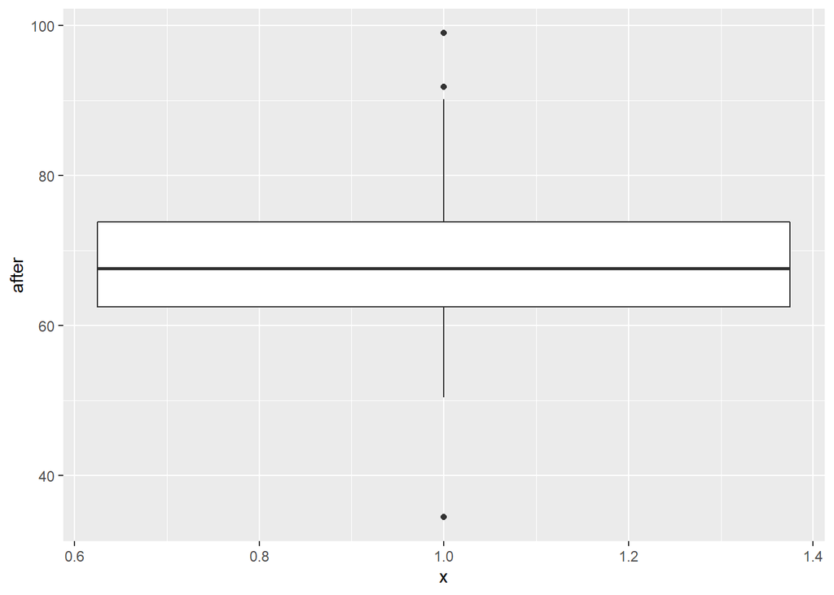

```r
ggplot(data = exercising) +
  geom_boxplot(mapping = aes(x=1, y=after))
```

Finally, we gonna do paired sample t-Test. Here, we need to set arguements `paired = TRUE` and still is able to change `conf.level` as the default setting is 0.95.

```r
t.test(exercising$before, exercising$after, paired = TRUE)
```

```
##
##  Paired t-test
##
## data:  exercising$before and exercising$after
## t = 2.5091, df = 99, p-value = 0.01373
## alternative hypothesis: true difference in means is not equal to 0
## 95 percent confidence interval:
##  0.7591711 6.4989461
## sample estimates:
## mean of the differences
##                3.629059
```

### Question

Now try simulate 100 people’s weight before and after exercising three time every week for a year again.  
You may use different types of function based on your hypothesis.  
Do some analysis and conduct paired sample test.